# Trabajo Final R

Guillermo Delgado

noviembre 27, 2019

# **Expresiones Regulares**

Vamos a comparar dos páginas web acerca de expresiones regulares:

- la primera página es [esta](http://www.diegocalvo.es/expresiones-regulares-en-r/)
- la segunda página es [esta](http://rpubs.com/ydmarinb/429756)

### **Primera página web**

La primera página tiene unas definición de lo que es una expresión regular y luego dividiendo la página en una parte de teoría en la que te explicas los diferentes símbolos que se utilizan en dichas expresiones seguido de una serie de ejemplos y acaba hablando sobre las diferentes funciones en las que se pueden utilizar expresiones regulares.

### **Segunda página web**

Por otro lado la segunda página tiene un formato distinto a la anterior. Empieza explicando las funciones donde puedes utilizar expresiones regulares explicando cada una de ellas y poniendo un ejemplo de cada una para despues hablar sobre los símbolos usando y acaba con una sección de comentarios bastante interesante para resolver las dudas de los usuarios.

### **Opinión**

Personalmente la primera página me parece mejor que la segunda por su estructuración y porque con la teoría, más allá de los ejemplos, puedes realizar todo tipo de cosas si dominas el tema pero no sabes todos los símbolos que se pueden llegar a utilizar. Es cierto que la segunda página tiene una sección de comentarios por si tienes alguna duda pero opino que no es tan importante debido a quew ya existen páginas como [Stack Overflow](https://es.stackoverflow.com/) o [Cran R](https://cran.r-project.org/) donde probablemente todas las preguntas de la página web se hayan resuelto ahí.

# **R-MarkDown**

También vamos a comparar dos páginas web acerca de R-MarkDown.

Las páginas web a comparar son las siguientes:

- Por un lado tenemos una página derivada del libro de R online [aqui](https://commonmark.org/help/)
- Por otro lado tenemos la introducción a R-MarkDown de la página web de **R Pubs** [aqui](http://www.rpubs.com/JohanMarin/Rmarkdown)

### **Primera página**

La primera página esta en inglés, lo cual no supone un problema y lo primero interesante que tiene es un link que pone *Try our 10 minute MarkDown tutorial* lo cual es interesante porque clickando en dicho link te lleva a un tutorial con una serie de lecciones donde cada lección te explica y te ayuda desde 0 a utilizar MarkDown. Dicho tutorial se puede encontrar [aqui](https://commonmark.org/help/tutorial/). Además cuenta algo de teoría (escasa a mi parecer).

### **Segunda página**

La segunda página tiene un índice en todo momento en la parte izquierda de la página web con el que nos podemos ir moviendo y saber nuestra ubicación dentro de dicha página. Comienza explicando qué es *R-MarkDown* y empieza de 0 ayudandote a configurar el documento, a crear el documento desde 0 y como crear un nuevo documento en formato *MarkDown*. A continuación empieza a explicar que comandos se pueden utilizar, como escribir código en el archivo o utilizar strings externos porque en ocasiones se quiere mostrar el contenido de strings previamente escrito. Por último habla sobre la existencia de diferentes temas que se pueden utilizar para personalizarlo y dejando en el documento la *galería de R-MarkDown*, y también sobre los diferentes paquetes externos que se pueden utilizar para embellecer las tablas o data frames que vayamos a mostrar en el archivo.

### **Opinión**

En mi opinión, me parece más práctica la primera página web debido a que existe un tutorial en el que puedes aprender progresivamente a utilizarlo. Sin embargo, en cuanto a cantidad de contenidos, me parece más completo la segunda página debido a que te explica como debes abrir el documento nuevo en R y todo lo que puedes hacer a la hora de inicializar el documento. Personalmente me quedo con la primera página web por ese tutorial que me parece muy interesante que tengan y que es algo dinámico, entretenido y que te ayuda a aprender de manera que no te puedas llegar a estresar mucho porque no sepas hacer algo.

# **Distritos de Madrid**

La ciudad de Madrid se compone de 21 distritos, que agrupan un total de 131 barrios administrativos. Para sacar dichos datos hemos realizado *web scrapping* en [esta página](https://es.wikipedia.org/wiki/Anexo:Distritos_de_Madrid) y de ahí hemos sacado una tabla con el nombre de los distritos, la población, la superficie, la densidad y los diferentes barrios de cada distrito.

Nuestros distritos serían los siguientes, en función de la densidad que tiene cada uno:

| Nombre | Superficie | Poblacion | Densidad | Barrios |
| --- | --- | --- | --- | --- |
| Centro | 522.82 | 131928 | 252.34 | Palacio (11)Embajadores (12)Cortes (13)Justicia (14)Universidad (15)Sol (16) |
| Arganzuela | 646.22 | 151965 | 235.16 | Imperial (21)Acacias (22)Chopera (23)Legazpi (24)Delicias (25)Palos de Moguer (26)Atocha (27) |
| Retiro | 546.62 | 118516 | 216.82 | Pacífico (31)Adelfas (32)Estrella (33)Ibiza (34)Jerónimos (35)Niño Jesús (36) |
| Salamanca | 539.24 | 143800 | 266.67 | Recoletos (41)Goya (42)Fuente del Berro (43)Guindalera (44)Lista (45)Castellana (46) |
| Chamartín | 917.55 | 143424 | 156.31 | El Viso (51)Prosperidad (52)Ciudad Jardín (53)Hispanoamérica (54)Nueva España (55)Castilla (56) |
| Tetuán | 537.47 | 153789 | 286.13 | Bellas Vistas (61)Cuatro Caminos (62)Castillejos (63)Almenara (64)Valdeacederas (65)Berruguete (66) |
| Chamberí | 467.92 | 137401 | 293.64 | Gaztambide (71)Arapiles (72)Trafalgar (73)Almagro (74)Ríos Rosas (75)Vallehermoso (76) |
| Fuencarral-El Pardo | 23783.84 | 238756 | 10.04 | El Pardo (81)Fuentelarreina (82)Peñagrande (83)Pilar (84)La Paz (85)Valverde (86)Mirasierra (87)El Goloso (88) |
| Moncloa-Aravaca | 4653.11 | 116903 | 25.12 | Casa de Campo (91)Argüelles (92)Ciudad Universitaria (93)Valdezarza (94)Valdemarín (95)El Plantío (96)Aravaca (97) |
| Latina | 2542.72 | 233808 | 91.95 | Los Cármenes (101)Puerta del Ángel (102)Lucero (103)Aluche (104)Campamento (105)Cuatro Vientos (106)Las Águilas (107) |
| Carabanchel | 1404.83 | 243998 | 173.68 | Comillas (111)Opañel (112)San Isidro (113)Vista Alegre (114)Puerta Bonita (115)Buenavista (116)Abrantes (117) |
| Usera | 777.77 | 134791 | 173.30 | Orcasitas (121)Orcasur (122)San Fermín (123)Almendrales (124)Moscardó (125)Zofío (126)Pradolongo (127) |
| Puente de Vallecas | 1496.86 | 227595 | 152.05 | Entrevías (131)San Diego (132)Palomeras Bajas (133)Palomeras Sureste (134)Portazgo (135)Numancia (136) |
| Moratalaz | 610.32 | 94197 | 154.34 | Pavones (141)Horcajo (142)Marroquina (143)Media Legua (144)Fontarrón (145)Vinateros (146) |
| Ciudad Lineal | 1142.57 | 212529 | 186.01 | Ventas (151)Pueblo Nuevo (152)Quintana (153)Concepción (154)San Pascual (155)San Juan Bautista (156)Colina (157)Atalaya (158)Costillares (159) |
| Hortaleza | 2741.98 | 180462 | 65.81 | Palomas (161)Piovera (162)Canillas (163)Pinar del Rey (164)Apóstol Santiago (165)Valdefuentes (166) |
| Villaverde | 2018.76 | 142608 | 70.64 | Villaverde Alto (171)San Cristóbal (172)Butarque (173)Los Rosales (174)Los Ángeles (175) |
| Villa de Vallecas | 5146.72 | 104421 | 19.86 | Casco Histórico de Vallecas (181)Santa Eugenia (182)Ensanche de Vallecas (183) |
| Vicálvaro | 3526.67 | 70051 | 19.86 | Casco Histórico de Vicálvaro (191)Valdebernardo (192)Valderrivas (193)El Cañaveral (194) |
| San Blas-Canillejas | 2229.24 | 154357 | 69.24 | Simancas (201)Hellín (202)Amposta (203)Arcos (204)Rosas (205)Rejas (206)Canillejas (207)Salvador (208) |
| Barajas | 4192.28 | 46876 | 11.18 | Alameda de Osuna (211)Aeropuerto (212)Casco Histórico de Barajas (213)Timón (214)Corralejos (215) |
| TOTAL | 60445.51 | 3182175 | 52.65 |  |

## **Distrito de San Blas**

[figure not shown]

Los datos los he sacado de la página web del [portal de datos de Madrid](https://datos.madrid.es/portal/site/egob/menuitem.c05c1f754a33a9fbe4b2e4b284f1a5a0/?vgnextoid=9d8a064b5ec1a510VgnVCM1000001d4a900aRCRD&vgnextchannel=374512b9ace9f310VgnVCM100000171f5a0aRCRD&vgnextfmt=default).

Estudiaremos los datos de todas las reservas de actividades deportivas realizadas en el año 2017 en 50 polideportivos públicos de la Comunidad de Madrid. Los datos estaban dispuestos en 12 hojas, un mes en cada hoja, en la que estaban todas las actividades de todos los polideportivos. Inicialmente, la idea era estudiar todos los polideportivos durante únicamente un solo mes. Pero debido a que los distintos centros polideportivos no siguen el mismo estándar para denominar a las mismas actividades, incluso el mismo polideportivo también llama de distinta forma a la misma actividad (diferenciando por espacios, mayúsculas, minúsculas, tildes, guiones, …) he decidido estudiar un solo centro polideportivo, pero durante todo el año 2017. Elegimos el polideportivo *San Blas* porque era el más conocido para mí, dado que paso muchos días por delante de él.

Para enfrentarme a estos datos sin depurar, me inspiré en Lloyd.

> ‘Orden a partir del caos’ - Frank Lloyd Wright

### **Variables y depuración**

- **Fecha:** Formato fecha: año-mes-día.
- **Día de la semana:** {Lunes, Martes, Miércoles, Jueves, Viernes, Sábado, Domingo}.
- **Hora de inicio:** La variable estaba en el formato: hora:minutos:segundos (la pasamos a numérica (las 9.75 serían las 9 y 45, por ejemplo)) para poder trabajar con ellas como datos numéricos.
- **Hora final:** La variable estaba en el formato: hora:minutos:segundos (igual a Hora Inicio).
- **Unidad deportiva:** Hemos reducido de manera exhaustiva sus niveles a la hora de limpiar. Teníamos 77 niveles y los hemos reducido a 55 (por mayúsculas, minúsculas, comillas,…)
- **Tipo de ocupación:** Indica el tipo de reserva de la actividad.
- **Uso:** Indica la actividad deportiva que se realiza, tras una limpieza exhaustiva entre mayúsculas, minúsculas, espacios, etc…. Reducida de 234 niveles a solo 23.
- **Centro deportivo:** En nuestro caso solo vamos a estudiar el polideportivo San Blas.

Creamos una columna adicional llamada Mes.

- **Mes:** {01 Enero, 02 Febrero, 03 Marzo, 04 Abril, 05 Mayo, 06 Junio, 07 Julio, 08 Agosto, 09 Septiembre, 10 Octubre, 11 Noviembre, 12 Diciembre}.

### **Análisis de los datos**

Vamos a analizar 3 cosas interesantes: La primera será el desempeño de cada actividad (que viene en función del uso) pintando un histograma como este

[interactive chart not shown]

Como podemos observar, durante todo el año, la actividad de natación es la que más se desempeña con 10.091 ocupaciones a lo largo del año seguida del entrenamiento de equipos federados y del pádel.

En segundo lugar, veremos otro histograma para analizar que tipo de reservas se realizan más en el polideportivo.

[interactive chart not shown]

En este histograma observamos que las reservas de escuela son las que más se realizan con bastante diferencia al resto (con 18.138 reservas en dicho año). Esto es debido a que al ser una zona residencial, existe mucha demanda de clases extraescolares para los niños que van al colegio.

#### **Un poco de investigación**

vamos a pintar un histograma, creando una variable nueva que tome dos valores, (si es de lunes a jueves o de viernes en adelante), donde analizaremos por mes y por día de la semana el número de reservas que hay.

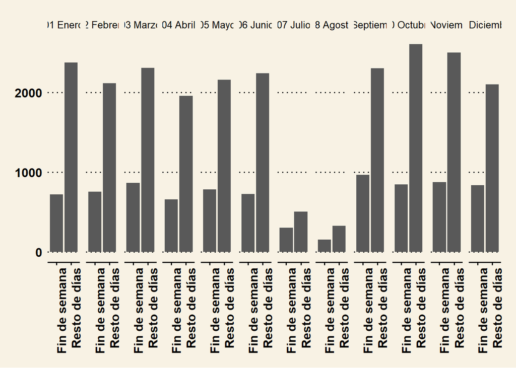

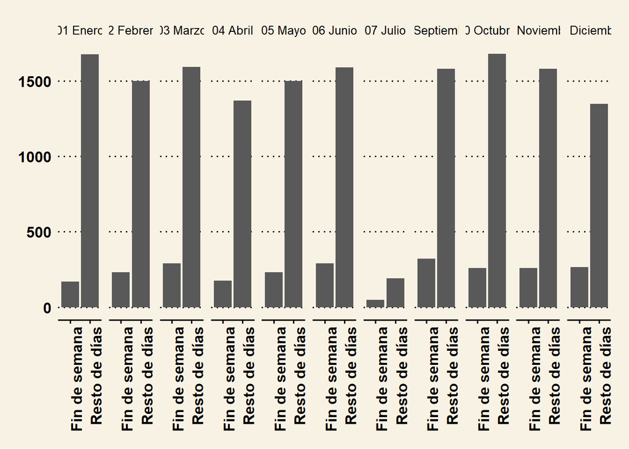

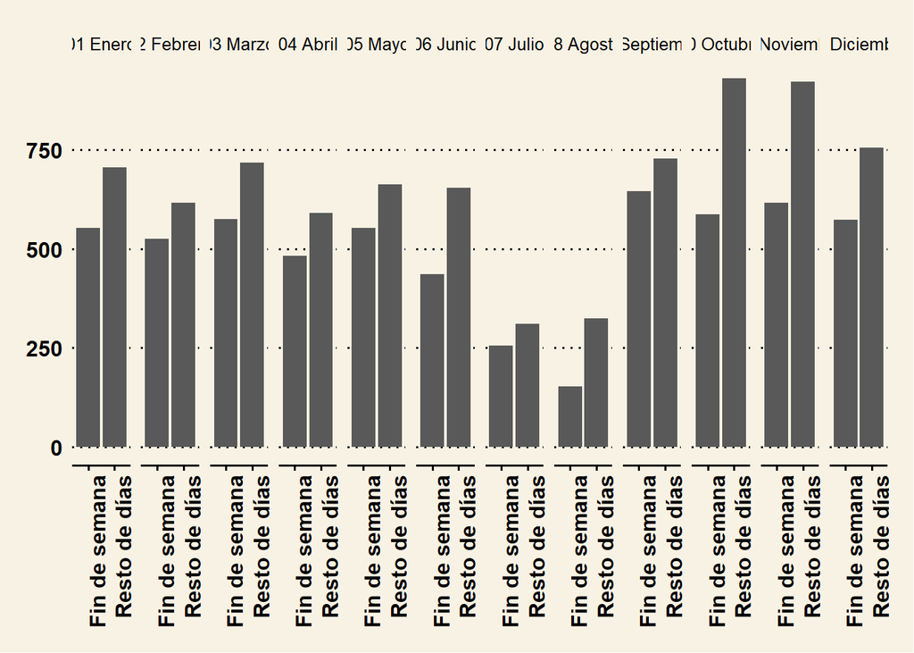